# Coursera Reproducible Research - Project 1 by Archer Lebron

This is the first assignment for the Coursera Reproducible Research. This assignment consists of the analysis of personal moving activity data that has been collected using monitoring devices such as Fitbit, Nike Fuelband, and/or Jawbone Up.

**Loading and preprocessing the data 1. Load the data 2. Process/transform the data (if necessary) into a format suitable for your analysis

```r
#Load the data
activity <- read.csv("activity.csv", header = TRUE)
head(activity)
```

```
##   steps       date interval
## 1    NA 2012-10-01        0
## 2    NA 2012-10-01        5
## 3    NA 2012-10-01       10
## 4    NA 2012-10-01       15
## 5    NA 2012-10-01       20
## 6    NA 2012-10-01       25
```

```r
class(activity$date)
```

```
## [1] "factor"
```

**What is mean total number of steps taken per day? 1. Calculate the total number of steps taken per day

```r
## Calculate the total number of steps taken per day
daysteps <- tapply(activity$steps, activity$date, sum, na.rm=TRUE)
daysteps
```

```
## 2012-10-01 2012-10-02 2012-10-03 2012-10-04 2012-10-05 2012-10-06
##          0        126      11352      12116      13294      15420
## 2012-10-07 2012-10-08 2012-10-09 2012-10-10 2012-10-11 2012-10-12
##      11015          0      12811       9900      10304      17382
## 2012-10-13 2012-10-14 2012-10-15 2012-10-16 2012-10-17 2012-10-18
##      12426      15098      10139      15084      13452      10056
## 2012-10-19 2012-10-20 2012-10-21 2012-10-22 2012-10-23 2012-10-24
##      11829      10395       8821      13460       8918       8355
## 2012-10-25 2012-10-26 2012-10-27 2012-10-28 2012-10-29 2012-10-30
##       2492       6778      10119      11458       5018       9819
## 2012-10-31 2012-11-01 2012-11-02 2012-11-03 2012-11-04 2012-11-05
##      15414          0      10600      10571          0      10439
## 2012-11-06 2012-11-07 2012-11-08 2012-11-09 2012-11-10 2012-11-11
##       8334      12883       3219          0          0      12608
## 2012-11-12 2012-11-13 2012-11-14 2012-11-15 2012-11-16 2012-11-17
##      10765       7336          0         41       5441      14339
## 2012-11-18 2012-11-19 2012-11-20 2012-11-21 2012-11-22 2012-11-23
##      15110       8841       4472      12787      20427      21194
## 2012-11-24 2012-11-25 2012-11-26 2012-11-27 2012-11-28 2012-11-29
##      14478      11834      11162      13646      10183       7047
## 2012-11-30
##          0
```

2. If you do not understand the difference between a histogram and a barplot, research the difference between them. Make a histogram of the total number of steps taken each day

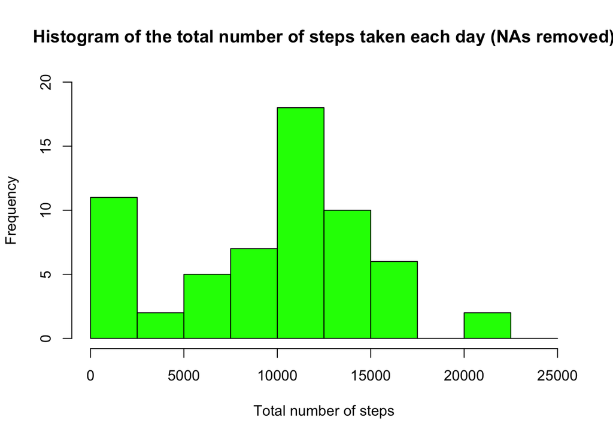

```r
# Histogram of the total number of steps taken each day
hist(daysteps, breaks=seq(from=0, to=25000, by=2500), col = "green", xlab="Total number of steps", ylim=c(0,20), main="Histogram of the total number of steps taken each day (NAs removed)")
```

3. Calculate and report the mean and median of the total number of steps per day

```r
# Mean of the total number of steps per day
mean(daysteps, na.rm = TRUE)
```

```
## [1] 9354.23
```

```r
# Median of the total number of steps per day
median(daysteps, na.rm = TRUE)
```

```
## [1] 10395
```

**What is the average daily activity pattern? 1. Make a time series plot (i.e. type =“1”) of the 5-minute interval (x-axis) and the average number of steps taken, averaged across all days (y-axis)

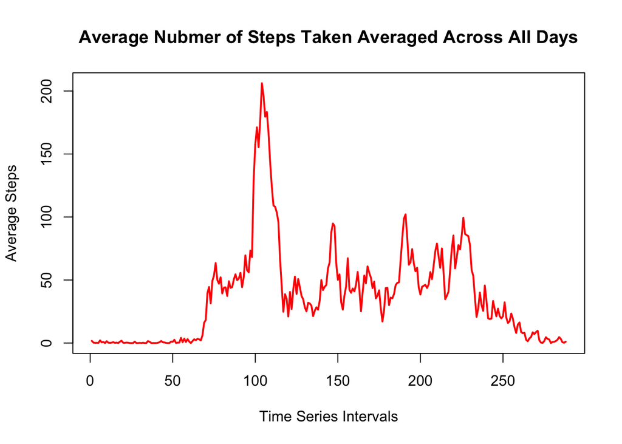

```r
# Calculate the average number of steps taken by each interval across all days
avgsteps <- tapply(activity$steps, activity$interval, mean, na.rm=TRUE)
# Plot a time series for the average number of steps taken, averaged across all days
plot(avgsteps, type = "l", col = "red", lwd = 2,xlab="Time Series Intervals", ylab = "Average Steps", main = "Average Nubmer of Steps Taken Averaged Across All Days")
```

2. Which 5-minute interval, on average across all the days in the dataset, contains the maximum number of steps?

```r
# Identify the interval with the maximum number of steps (sort in decreasing order)
sort(avgsteps, decreasing = TRUE)
```

[output not shown]

[output cut: 41 more lines]

[output not shown]

**Imputing missing values 1. Calculate and report the total number of missing values in the dataset (i.e. the total number of rows with 𝙽𝙰s)

```r
# Calculate the total number of NAs
Total_NA <- sum(is.na(activity))
Total_NA
```

```
## [1] 2304
```

2. Devise a strategy for filling in all of the missing values in the dataset. The strategy does not need to be sophisticated. For example, you could use the mean/median for that day, or the mean for that 5-minute interval, etc.

```r
# Identify the index positions of the NAs
na_ind <- which(is.na(activity$steps))
# Create a vector the length of total NAs with the average of steps throughout all the days
meanvec <- rep(mean(activity$steps, na.rm=TRUE), times = length(na_ind))
```

3. Create a new dataset that is equal to the original dataset but with the missing data filled in.

```r
# Replace missing values (NAs) with the average value of steps
activity[is.na(activity)] <- meanvec
```

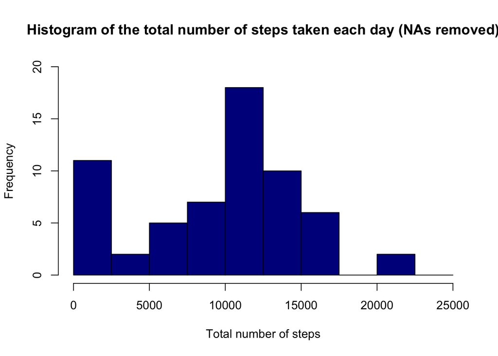

```r
# Histogram of the total number of steps taken each day
hist(daysteps, breaks=seq(from=0, to=25000, by=2500), col = "dark blue", xlab="Total number of steps", ylim=c(0,20), main="Histogram of the total number of steps taken each day (NAs removed)")
```

```r
# Calculate the mean total number of steps taken per day
mean(daysteps)
```

```
## [1] 9354.23
```

```r
# Calculate the median total number of steps take per day
median(daysteps)
```

```
## [1] 10395
```

**Are there differences in activity patterns between weekdays and weekends? 1. Create a new factor variable in the dataset with two levels – “weekday” and “weekend” indicating whether a given date is a weekday or weekend day.

```r
# Convert dates factor variable to Date
activity$date <- as.Date(activity$date)
class(activity$date)
```

```
## [1] "Date"
```

```r
# Create a vector of weekdays
weekdays0 <- c('Monday', 'Tuesday', 'Wednesday', 'Thursday', 'Friday')
# Use '%in%' and 'weekdays' to create a logical vector
activity$Daytype <- factor((weekdays(activity$date) %in% weekdays0), levels=c(FALSE,TRUE), labels=c('weekend', 'weekday'))
head(activity)
```

```
##     steps       date interval Daytype
## 1 37.3826 2012-10-01        0 weekday
## 2 37.3826 2012-10-01        5 weekday
## 3 37.3826 2012-10-01       10 weekday
## 4 37.3826 2012-10-01       15 weekday
## 5 37.3826 2012-10-01       20 weekday
## 6 37.3826 2012-10-01       25 weekday
```

2. Make a panel plot containing a time series plot (i.e. 𝚝𝚢𝚙𝚎 = “𝚕”) of the 5-minute interval (x-axis) and the average number of steps taken, averaged across all weekday days or weekend days (y-axis). See the README file in the GitHub repository to see an example of what this plot should look like using simulated data.

```r
# Load the lattice graphical library
library(lattice)

# Compute the average number of steps taken, averaged across all daytype variable
days_mean <- aggregate(activity$steps, by=list(activity$Daytype, activity$interval),mean)

# Rename the attributes
names(days_mean) <- c("daytype", "interval", "mean")
head(days_mean)
```

```
##   daytype interval     mean
## 1 weekend        0 4.672825
## 2 weekday        0 7.006569
## 3 weekend        5 4.672825
## 4 weekday        5 5.384347
## 5 weekend       10 4.672825
## 6 weekday       10 5.139902
```

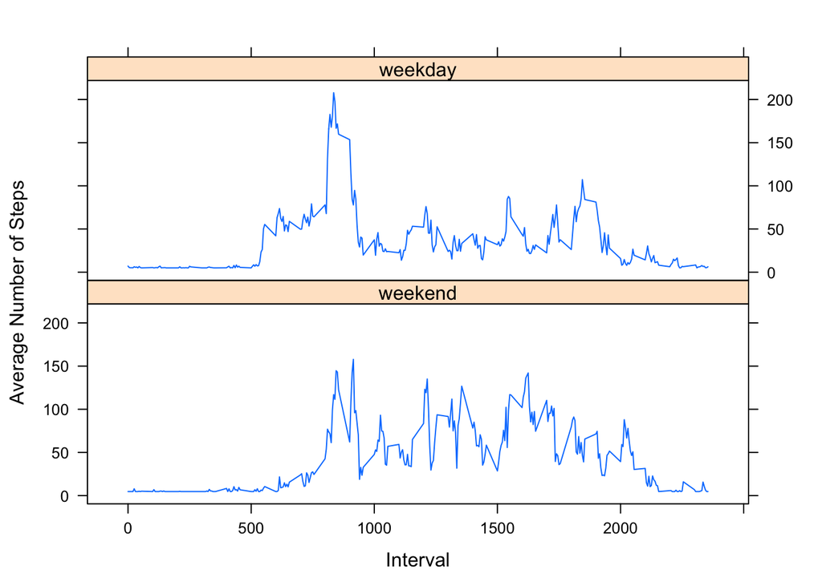

```r
# Compute the time series plot
xyplot(mean ~ interval | daytype, days_mean, type="l", lwd=1, xlab="Interval", ylab="Average Number of Steps", layout=c(1,2))
```